# Gun Violence in the U.S.

Stephanie Liu (sliu39@uw.edu), Daphne He (daphnehe@uw.edu), Cecelia Thomas (ceceliat@uw.edu)

Autumn 2022

### Dynamic paragraph

Of the gun death victims from 1985 to 2018, 304 were less than one years old. The percentage of male offenders is 93% and the percentage of female offenders is 7%. The percentage of Black victims is 54%. The percentage of gun deaths caused by handguns is 76%. Through these values, we can see various trends in the data that show the severity of gun violence in the U.S.

| Gender | counts |
| --- | --- |
| Female | 5 |
| M | 20 |
| M/F | 1 |
| Male | 272 |
| Male/Female | 4 |
| Unknown | 21 |

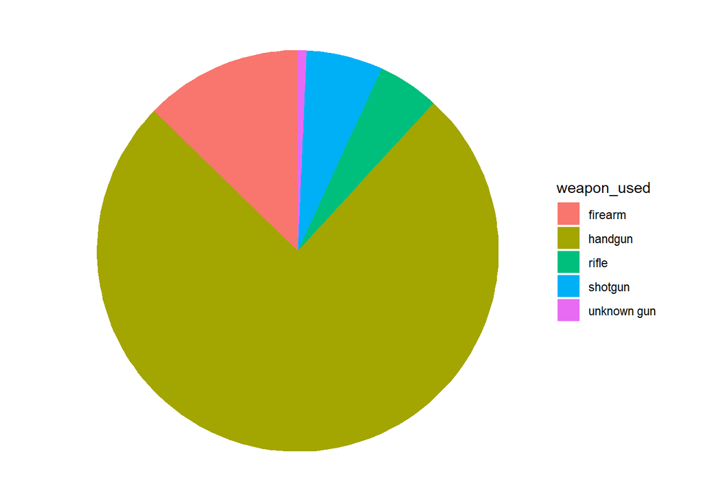

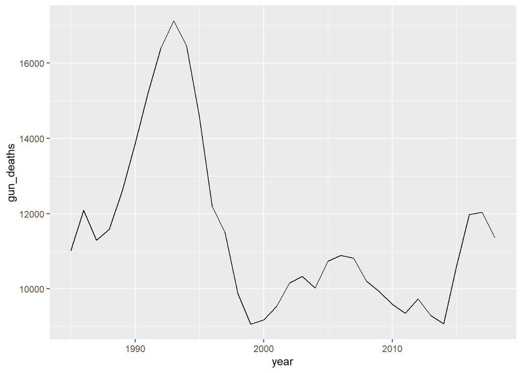

This visualization represents the amount of gun deaths over a span of 33 years from 1985 to 2018. The amount of deaths seem to have peaked sometime in between the years 1990 and 2000. The amount of deaths seems to be at the lowest before 2000 and after 2010.

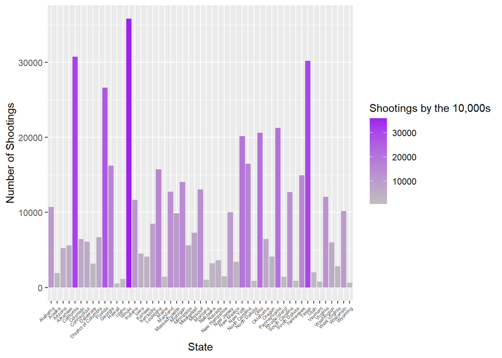

This visualization represents the number of shootings per state, including the District of Columbia, from the years 2013-2022. This chart further illustrates which states gun incidents have occurred most often. Illinois, California, Texas, and Florida are seen to have had the most gun related incidents from 2013 to 2022.